# MOM6 Subsurface Heatwaves

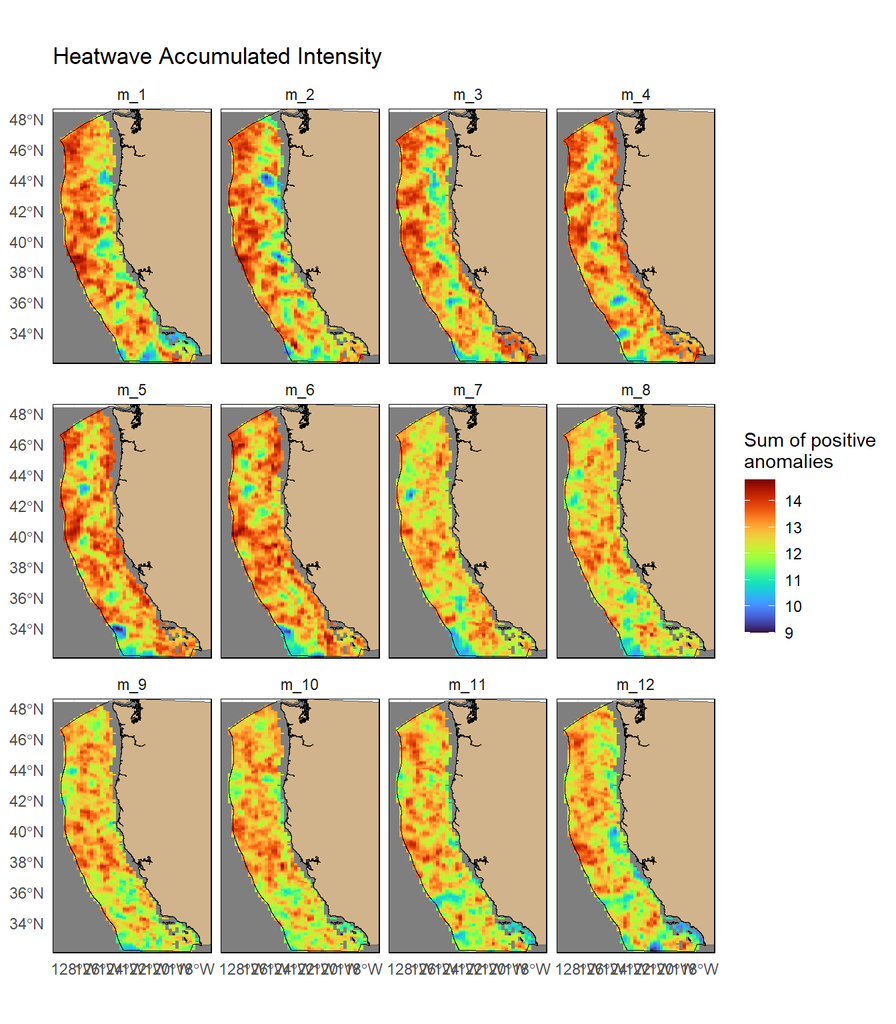

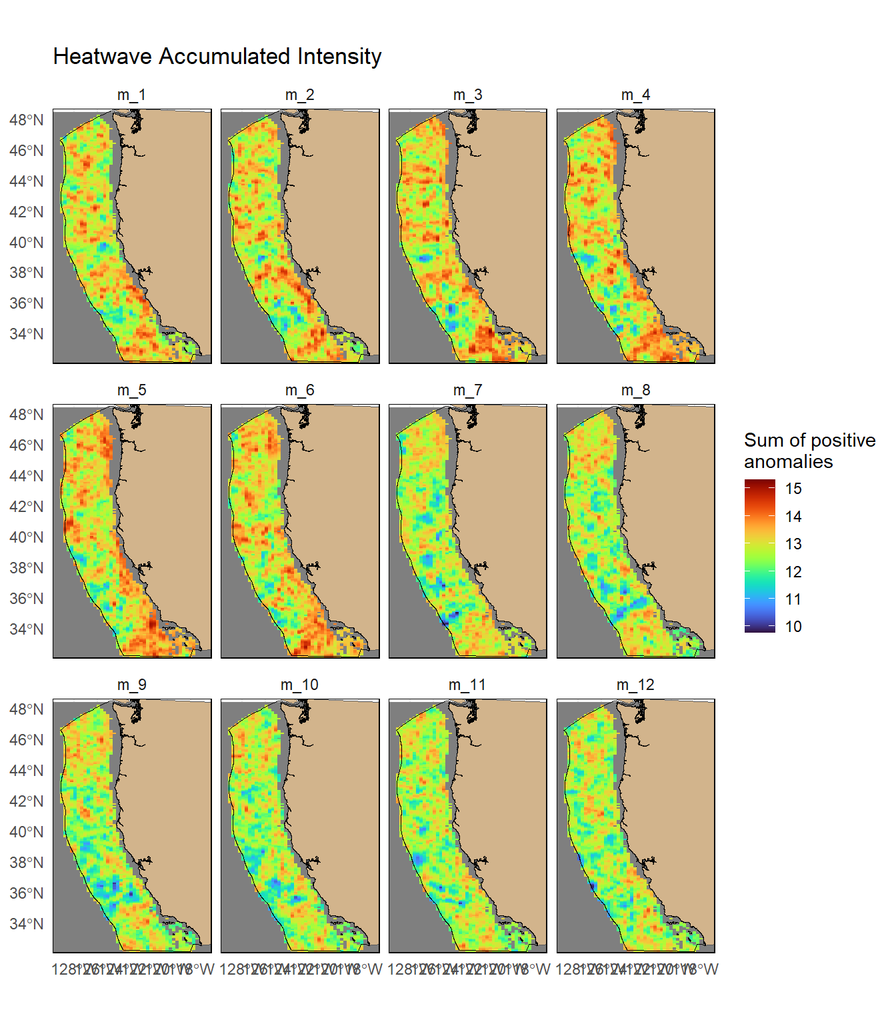

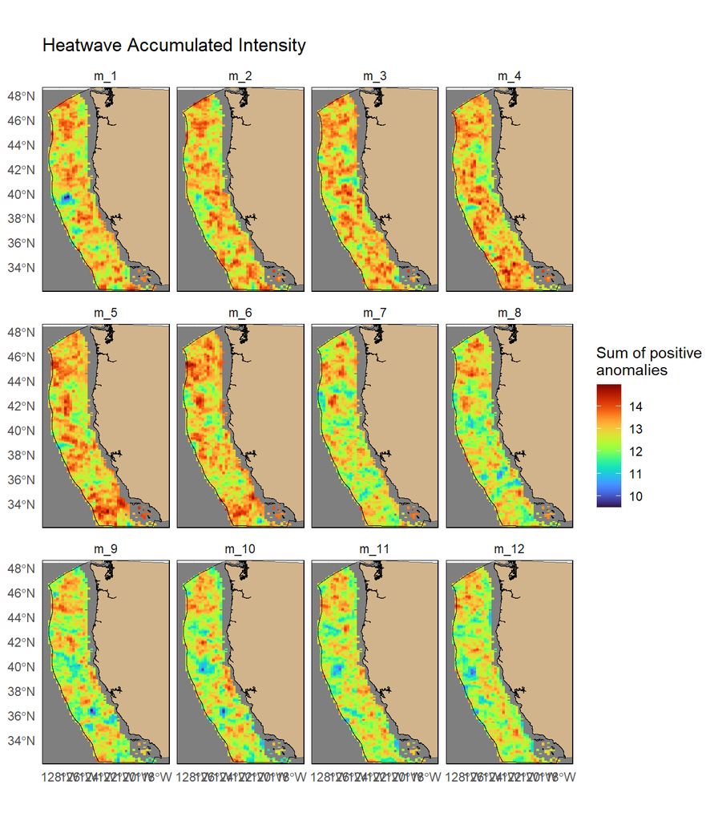

Areas with sustained heatwaves (consecutive months exceeding threshold)

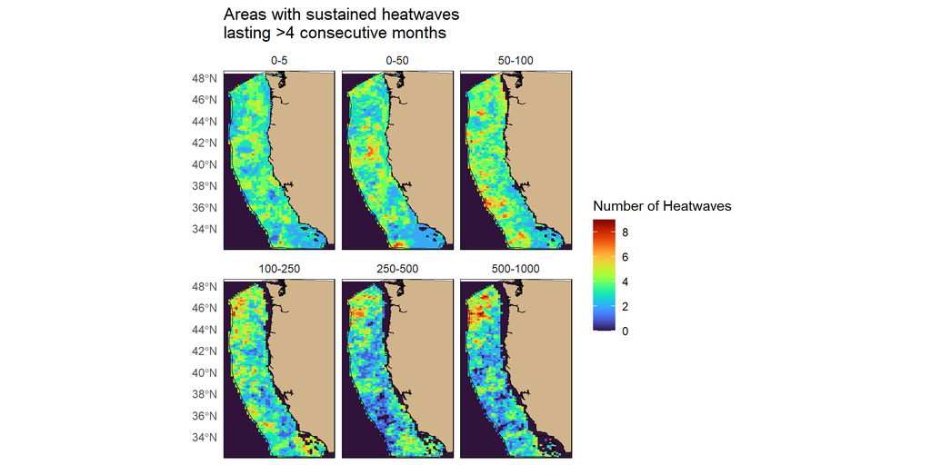

## Breakpoint Analysis

Using the time series of OHC anomalies, test for breakpoints. Here’s a general function to test all plausible breakpoint months using 3 different possible breakpoint models: a piecewise but continuous linear, a discontinuous linear, or a mean shift.

Using the top (surface) depth layer, test the breakpoint calculations.

```
[1] 254
```

```
[1] 244 256
```

```
Call:
lm(formula = y ~ I(tidx > bp), data = df)

Residuals:
     Min       1Q   Median       3Q      Max
-1.96298 -0.54693 -0.09042  0.52940  2.14377

Coefficients:
                 Estimate Std. Error t value Pr(>|t|)
(Intercept)      -0.20631    0.04798  -4.300 2.17e-05 ***
I(tidx > bp)TRUE  0.59163    0.08126   7.281 1.86e-12 ***
---
Signif. codes:  0 '***' 0.001 '**' 0.01 '*' 0.05 '.' 0.1 ' ' 1

Residual standard error: 0.7647 on 388 degrees of freedom
Multiple R-squared:  0.1202,    Adjusted R-squared:  0.1179
F-statistic: 53.01 on 1 and 388 DF,  p-value: 1.86e-12
```

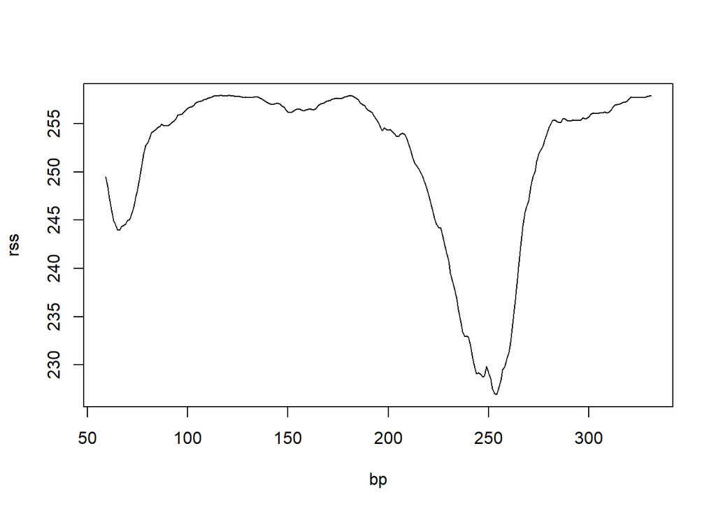

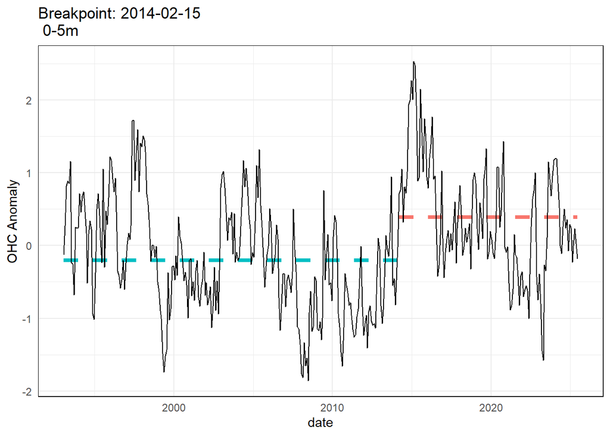

Test a continuous linear with one breakpoint

```
[1] 185
```

```
[1] 168 203
```

```
Call:
lm(formula = y ~ tidx + pmax(tidx - bp, 0), data = df)

Residuals:
     Min       1Q   Median       3Q      Max
-1.94487 -0.58558 -0.07751  0.48988  2.59967

Coefficients:
                     Estimate Std. Error t value Pr(>|t|)
(Intercept)         0.3754133  0.1068715   3.513 0.000496 ***
tidx               -0.0043667  0.0008345  -5.233 2.74e-07 ***
pmax(tidx - bp, 0)  0.0088339  0.0014026   6.298 8.20e-10 ***
---
Signif. codes:  0 '***' 0.001 '**' 0.01 '*' 0.05 '.' 0.1 ' ' 1

Residual standard error: 0.7763 on 387 degrees of freedom
Multiple R-squared:  0.09584,   Adjusted R-squared:  0.09117
F-statistic: 20.51 on 2 and 387 DF,  p-value: 3.416e-09
```

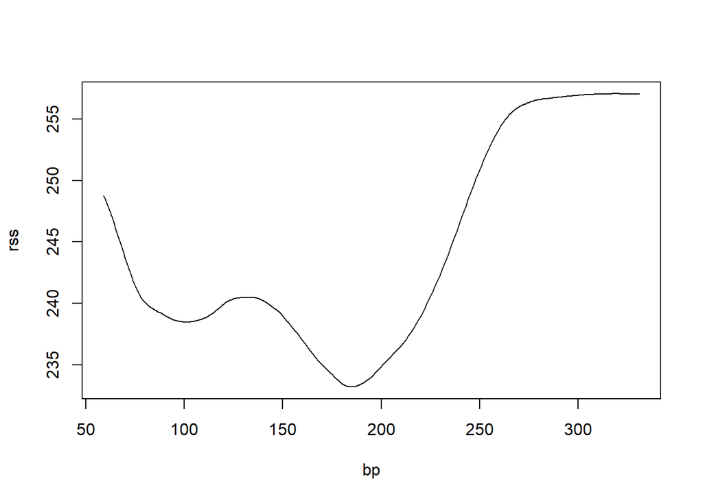

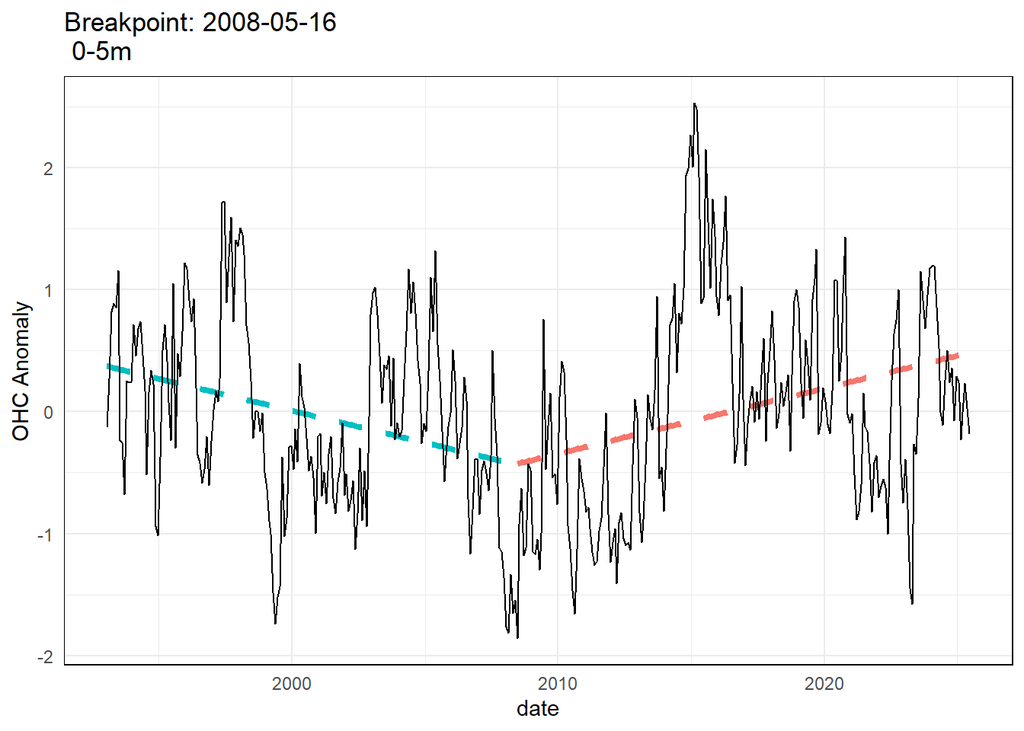

And finally, a piecewise, discontinuous linear

```
[1] 254
```

```
[1] 253 254
```

```
Call:
lm(formula = y ~ tidx * I(tidx > bp), data = df)

Residuals:
     Min       1Q   Median       3Q      Max
-1.76297 -0.48976 -0.05786  0.48412  1.70710

Coefficients:
                        Estimate Std. Error t value Pr(>|t|)
(Intercept)            0.3756576  0.0859125   4.373 1.58e-05 ***
tidx                  -0.0045645  0.0005841  -7.814 5.30e-14 ***
I(tidx > bp)TRUE       3.0487695  0.4919303   6.198 1.47e-09 ***
tidx:I(tidx > bp)TRUE -0.0048591  0.0016013  -3.035  0.00257 **
---
Signif. codes:  0 '***' 0.001 '**' 0.01 '*' 0.05 '.' 0.1 ' ' 1

Residual standard error: 0.6826 on 386 degrees of freedom
Multiple R-squared:  0.3027,    Adjusted R-squared:  0.2973
F-statistic: 55.85 on 3 and 386 DF,  p-value: < 2.2e-16
```

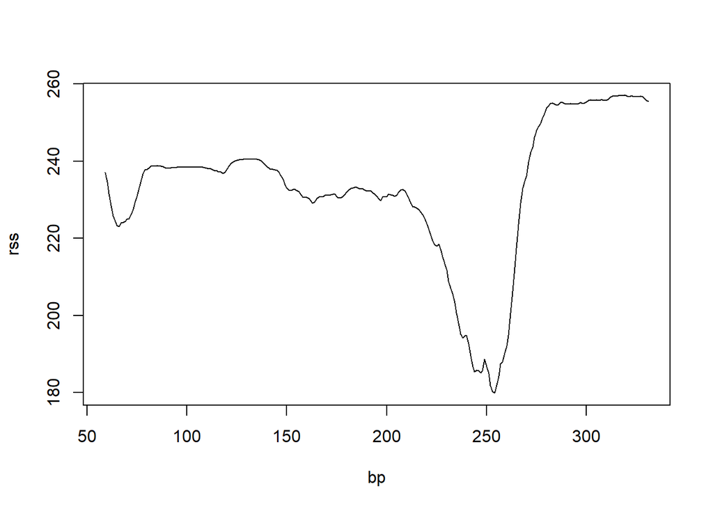

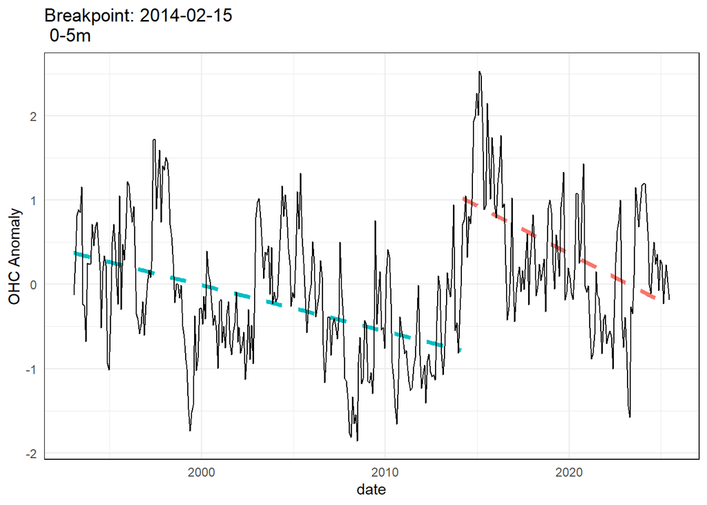

Really interesting that both the mean shift and the discontinous linear identify February, 2014 as the month of the “regime shift” into the new MHW era.

Let’s try this for all the depth layers, using the discontinuous linear.

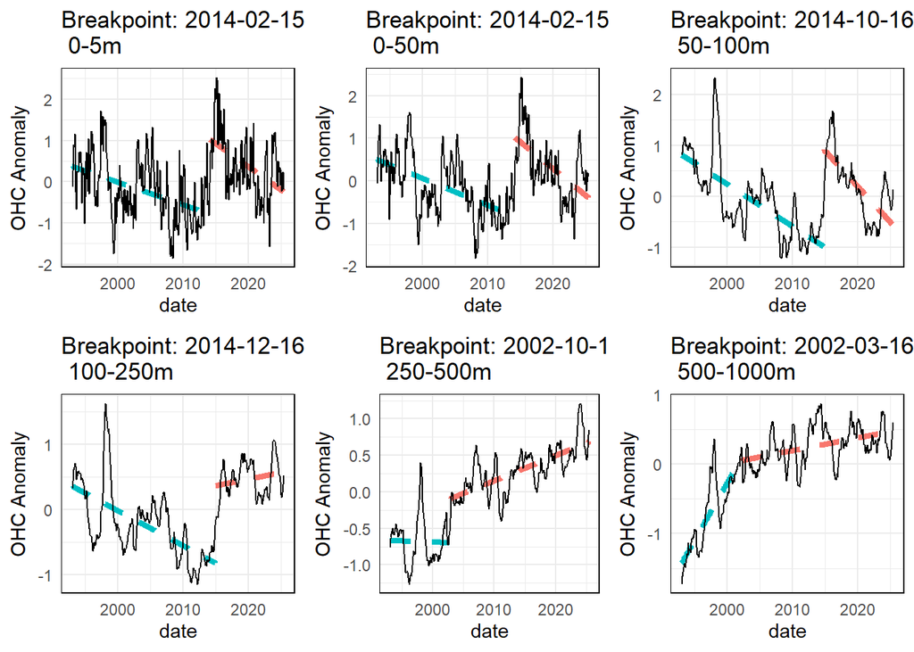

We can try to do the same breakpoint analysis with the area-normalized time series.

Run a mean-shift breakpoint analysis on the area time series

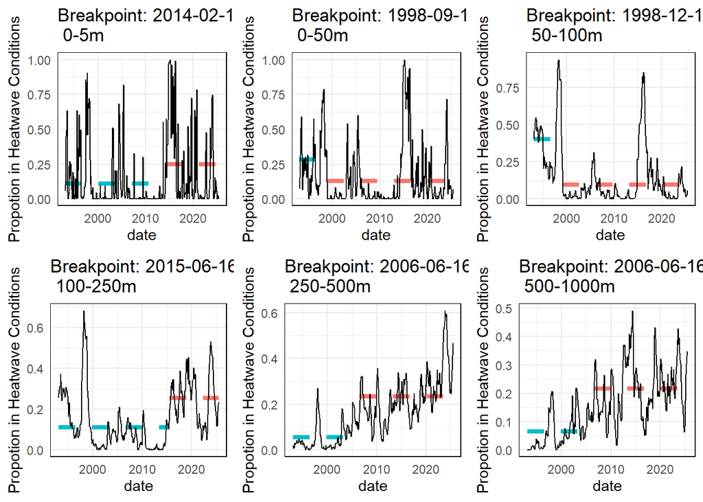